# Basic Linear Modeling

Sean Kross

January 13, 2016

### Simple Linear Regression

For our exploration of linear modeling we’re going to use a dataset that comes packaged with R called `trees`. This dataset contains information about the girth, height, and volume of 31 trees. Use `help("trees")` for more infromation about this dataset. Let’s examine the relationship between the girth and the volume of these trees by plotting them:

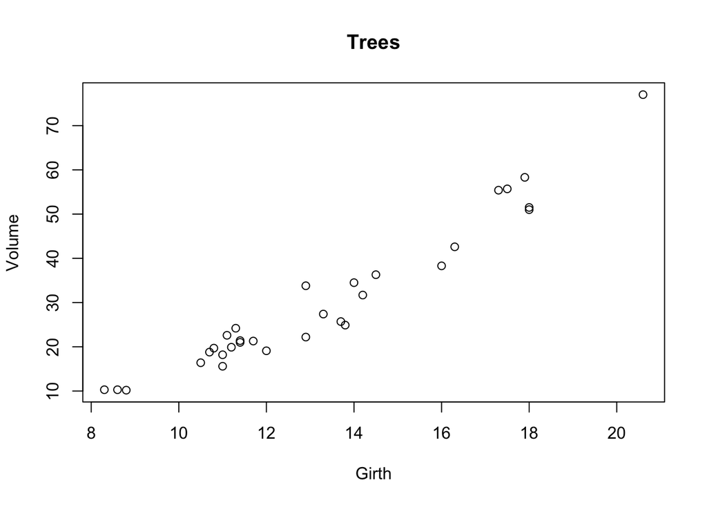

```r
plot(trees$Girth, trees$Volume, xlab = "Girth", ylab = "Volume", main = "Trees")
```

At first glace it looks like there’s a relationship! You could imagine drawing a straight line through most of the points on this graph, and even the points that you missed would be close to the line. This “strightness” is called a linear relationship. R provides functions for modeling linear relationships and other kinds of relationships between data. The most simple of these functions is the `lm()` function. To use the `lm()` function you need to provide a formula, which represents a relationship between variables, and a data frame that maps the variables in the formula to columns in the data frame. I’ll use `lm()` now to construct a model of the relationship between tree volume and girth:

```r
tree_model1 <- lm(Volume ~ Girth, data = trees)
tree_model1
```

```
##
## Call:
## lm(formula = Volume ~ Girth, data = trees)
##
## Coefficients:
## (Intercept)        Girth
##     -36.943        5.066
```

The model itself is an advanced data structure that resembles a list. When I examine the `tree_model1` variable on the R console it prints the y-axis intercept of the regression line and the slope of the regression line. Let’s draw the regression line using `abline()`.

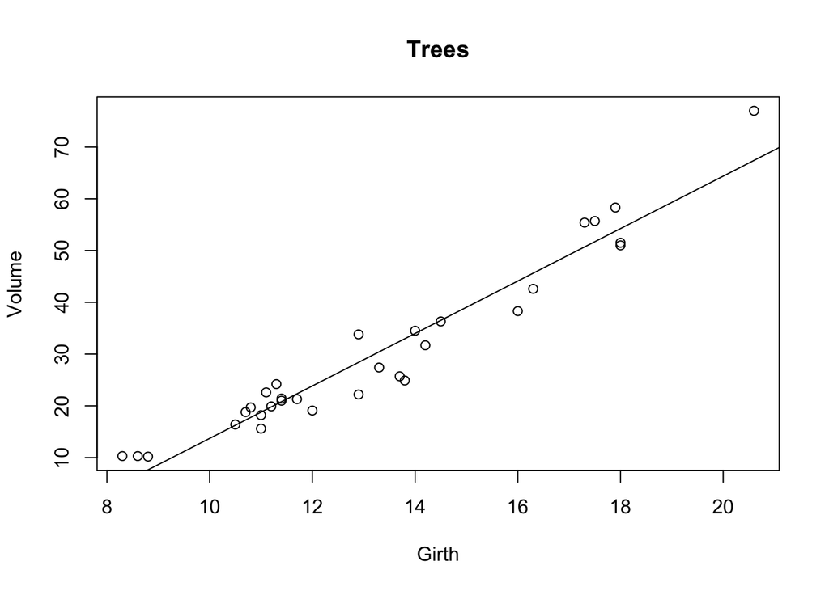

```r
plot(trees$Girth, trees$Volume, xlab = "Girth", ylab = "Volume", main = "Trees")
abline(tree_model1)
```

```r
predictions1 <- predict(tree_model1, data.frame(Girth = 11:14))
predictions1
```

```
##        1        2        3        4
## 18.78096 23.84682 28.91267 33.97853
```

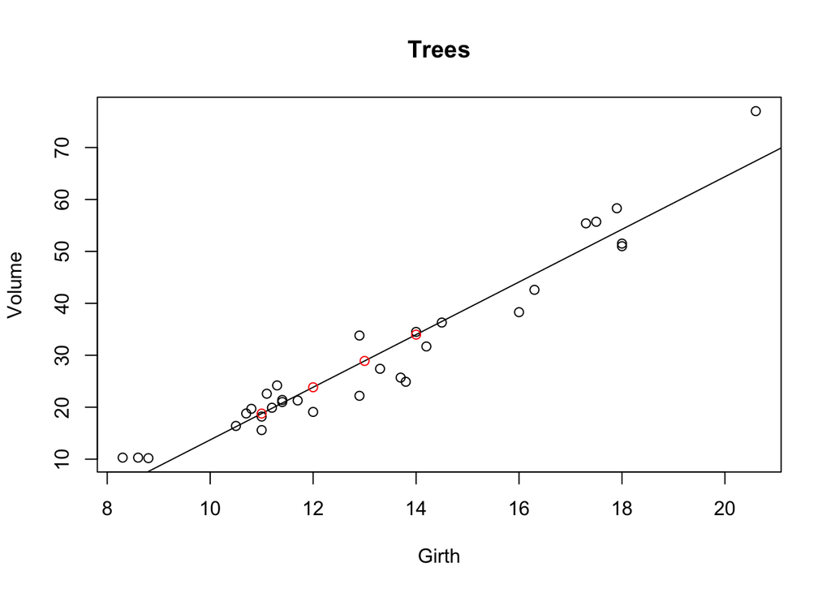

```r
plot(trees$Girth, trees$Volume, xlab = "Girth", ylab = "Volume", main = "Trees")
abline(tree_model1)
points(11:14, predictions1, col = "red")
```

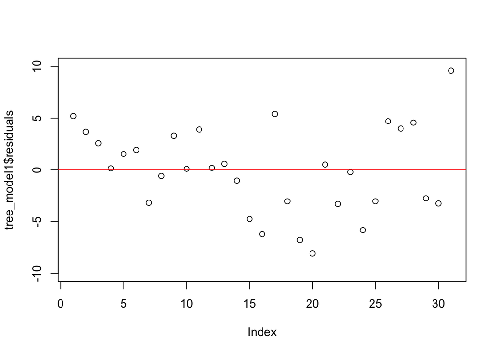

```r
plot(tree_model1$residuals, ylim = c(-10, 10))
abline(h = 0, col = "red")
```

### Multiple Linear Regression

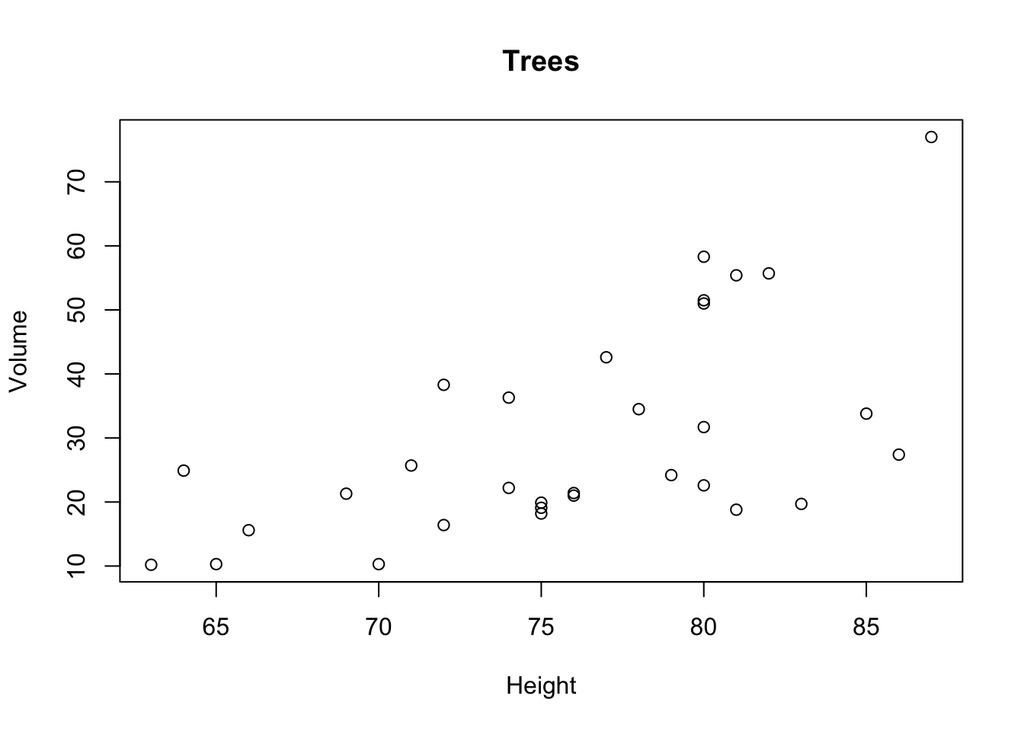

```r
plot(trees$Height, trees$Volume, xlab = "Height", ylab = "Volume", main = "Trees")
```

```r
tree_model2 <- lm(Volume ~ Girth + Height, data = trees)
tree_model2
```

```
##
## Call:
## lm(formula = Volume ~ Girth + Height, data = trees)
##
## Coefficients:
## (Intercept)        Girth       Height
##    -57.9877       4.7082       0.3393
```

```r
predictions2 <- predict(tree_model2, data.frame(Girth = c(12, 14, 16),
                                                Height = c(70, 73, 76)))
predictions2
```

```
##        1        2        3
## 22.25785 32.69193 43.12600
```

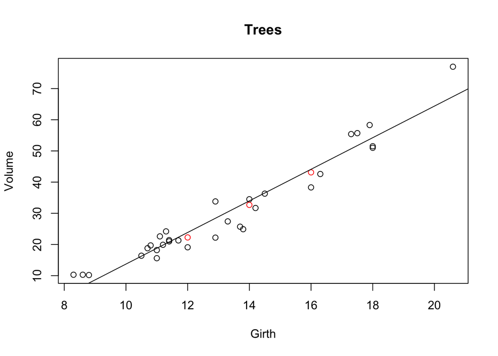

```r
plot(trees$Girth, trees$Volume, xlab = "Girth", ylab = "Volume", main = "Trees")
points(c(12, 14, 16), predictions2, col = "red")
abline(tree_model1)
```

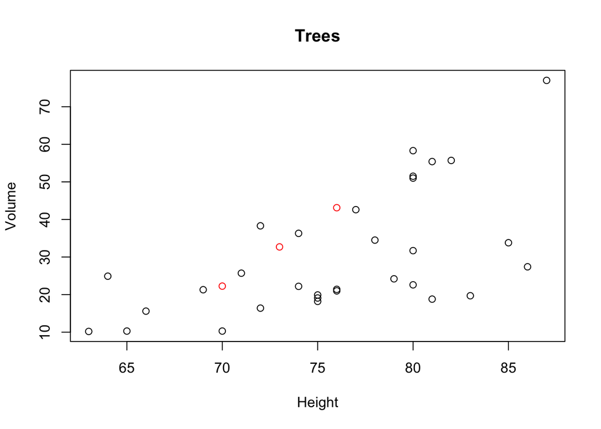

```r
plot(trees$Height, trees$Volume, xlab = "Height", ylab = "Volume", main = "Trees")
points(c(70, 73, 76), predictions2, col = "red")
```

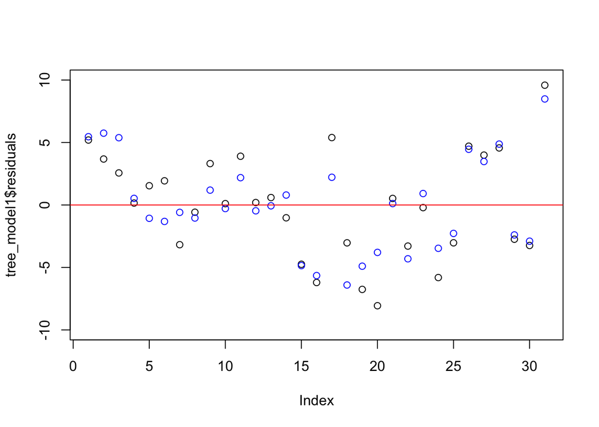

```r
plot(tree_model1$residuals, ylim = c(-10, 10))
points(tree_model2$residuals, ylim = c(-10, 10), col = "blue")
abline(h = 0, col = "red")
```